# eea2019_tp1_RiosPaez_GustavoArturo

#a.Obtener la cantidad de valores unicos y de valores faltantes (NAs) para cada una de estas variables #Ahora vamos a totalizar los valores faltantes por columnap para esto usamos la función apply para sumar #sobre los resultados de la misma función para listar los is.na por columna #inceptionTime

```r
apply(apply(ar_properties_filtrado,2,is.na),2,sum)
```

```
##              id              l3           rooms        bedrooms
##               0             136            1975            9861
##       bathrooms   surface_total surface_covered           price
##            1211            1444            1174               0
##   property_type
##               0
```

#b.Obtener la matriz de correlacion para las variables numericas. #Para las correlaciones usaremos la librería corrr

```r
library(tidyverse)
library(corrr)
library(corrplot)
```

#Separaremos las variables numéricas

```r
numeric_variables <-  ar_properties_filtrado %>%
  select(rooms, bedrooms, bathrooms, surface_total, surface_covered, price)
glimpse(numeric_variables)
```

```
## Observations: 24,323
## Variables: 6
## $ rooms           <fct> NA, 6, NA, 3, NA, 3, 1, 1, 1, 1, 1, 1, 1, 1, 1...
## $ bedrooms        <fct> NA, NA, NA, NA, NA, NA, NA, NA, NA, NA, NA, NA...
## $ bathrooms       <fct> NA, 2, 2, 4, 1, 2, 1, 1, 1, 1, 1, 1, 1, 1, 1, ...
## $ surface_total   <fct> 300, 178, 240, 157, 140, 95, 44, 40, 49, 40, 4...
## $ surface_covered <fct> 180, 240, 157, NA, 110, 69, 38, 37, 44, 37, 37...
## $ price           <fct> 320000, 500000, 350000, 470000, 155000, 199900...
```

#Transformamos las variables categóricas en numéricas

```r
numeric_variables <- apply(apply(numeric_variables,2,as.character), 2, as.numeric)
crm <- cor(numeric_variables, use="complete.obs", method="pearson")
crm
```

```
##                      rooms   bedrooms  bathrooms surface_total
## rooms           1.00000000 0.92979527 0.60318421    0.06364667
## bedrooms        0.92979527 1.00000000 0.61396803    0.06507773
## bathrooms       0.60318421 0.61396803 1.00000000    0.05664833
## surface_total   0.06364667 0.06507773 0.05664833    1.00000000
## surface_covered 0.05561538 0.05684364 0.05071377    0.98901389
## price           0.47595400 0.42622405 0.59618271    0.04477758
##                 surface_covered      price
## rooms                0.05561538 0.47595400
## bedrooms             0.05684364 0.42622405
## bathrooms            0.05071377 0.59618271
## surface_total        0.98901389 0.04477758
## surface_covered      1.00000000 0.04006500
## price                0.04006500 1.00000000
```

#Generámos la matriz de corelaciones

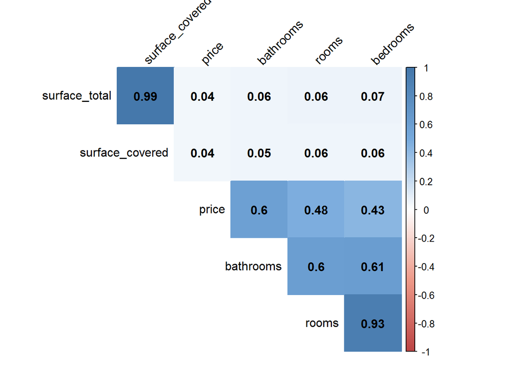

```r
library(RColorBrewer)
library(corrplot)
n <- ncol(crm)
p.mat<- matrix(NA, n, n)
col <- colorRampPalette(c("#BB4444", "#EE9988", "#FFFFFF", "#77AADD", "#4477AA"))
corrplot(crm, method="color", col=col(200),
         type="upper", order="hclust",
         addCoef.col = "black", # Add coefficient of correlation
         tl.col="black", tl.srt=45, #Text label color and rotation
         # Combine with significance
         p.mat = p.mat, sig.level = 0.01, insig = "blank",
         # hide correlation coefficient on the principal diagonal
         diag=FALSE
)
```

#Encontramos que: #Todas las correlaciones entre las varialbes son positivas. #Contra la hipótesis inicial no se observa una correlaciónmarcada entre la superficie cubierta y el precio #Se observauna correlaciónentre el precio y el número de baños y cuartos

#3.Preparacion de los datos (II) #a.En el punto 2 deberian haber encontrado que la variable bedrooms presenta una alta #proporción de valores faltantes y que presenta una fuerte correlacion con la variable rooms. #Por lo tanto, vamos a eliminarla. #Nota: surface_total y surface_covered también están estrechamente correlacionadas

```r
ar_properties_filtrado <- ar_properties_filtrado %>% select(-bedrooms)
```

#b.Eliminar todos los registros que presentan valores faltantes #Para esto usaremos la función drop_na de tidyr

```r
library(tidyr)
ar_properties_filtrado <- ar_properties_filtrado %>% drop_na()
ar_properties_filtrado
```

|  | id | l3 | rooms | bathrooms | surface_total | surface_covered | price | property_type |
| --- | --- | --- | --- | --- | --- | --- | --- | --- |
| 2 | HdjpKrqdwYfH9YU1DKjltg== | Boedo | 6 | 2 | 178 | 240 | 500000 | Casa |
| 6 | AfdcsqUSelai1ofCAq2B0Q== | Velez Sarsfield | 3 | 2 | 95 | 69 | 199900 | Casa |
| 7 | ESzybdH7YU2uIU1/kHtRGw== | NuÃ±ez | 1 | 1 | 44 | 38 | 147000 | Departamento |
| 8 | r22OfzZ3kXooSPoE5HMuZQ== | Almagro | 1 | 1 | 40 | 37 | 92294 | Departamento |
| 9 | atZQXVtyfG7+OiX6gYY3lA== | Almagro | 1 | 1 | 49 | 44 | 115000 | Departamento |
| 10 | R7IsTtVsxPCiRbIHMaWGxA== | Almagro | 1 | 1 | 40 | 37 | 77000 | Departamento |
| 11 | Tur/v/qE41UBT83NM/bI7w== | Almagro | 1 | 1 | 40 | 37 | 88900 | Departamento |
| 12 | PNtNl6sWjHEyRPQAeRAIgw== | Almagro | 1 | 1 | 40 | 37 | 88798 | Departamento |
| 13 | Lhg4dNG9VmPbHt0Swy2ATA== | Almagro | 1 | 1 | 49 | 44 | 110975 | Departamento |
| 14 | MFngc+8f1sFriO+lteUuZw== | Almagro | 1 | 1 | 40 | 37 | 92943 | Departamento |

[output cut: 9990 more lines]

#4.Analisis exploratorios (II) #a.Obtener estadisticas descriptivas para la variable precio (cuartiles, promedio, minimo y maximo) y #realizar un histograma de la variable

```r
summaryPrecio <- summary(as.numeric(as.character(ar_properties_filtrado$price)))
summaryPrecio
```

```
##    Min. 1st Qu.  Median    Mean 3rd Qu.    Max.
##    6000  117000  169000  250258  270000 6000000
```

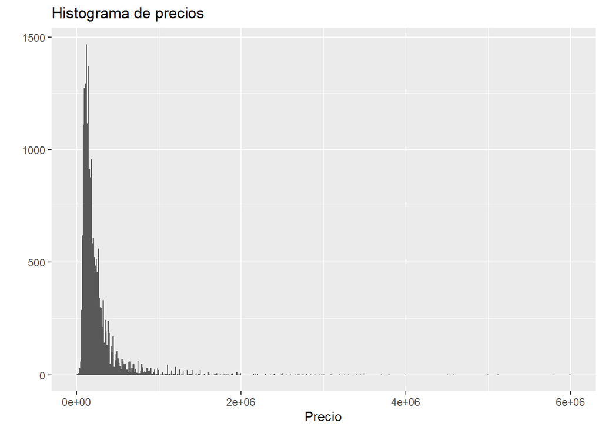

```r
priceHistogram <- qplot(as.numeric(as.character(ar_properties_filtrado$price)),
                        geom="histogram",
                        main = "Histograma de precios",
                        xlab = "Precio",
                        bins = 500)
priceHistogram
```

#Como vemos el histograma se ve algo distorsionado por los valores extremos que tiene #la variable price

#b.Obtener estadisticas descriptivas para la variable precio #(cuartiles, promedio, minimo y maximo) por cada tipo de propiedad.

```r
summaryPrecioPorTipo <- summary(as.numeric(as.character(ar_properties_filtrado$price)))
summaryPrecioPorTipo <- tapply(as.numeric(as.character(ar_properties_filtrado$price)),
                              ar_properties_filtrado$property_type, summary)
summaryPrecioPorTipo <- summaryPrecioPorTipo[c("PH","Departamento","Casa")]
summaryPrecioPorTipo
```

```
## $PH
##    Min. 1st Qu.  Median    Mean 3rd Qu.    Max.
##   42000  134450  189000  215670  270000 1200000
##
## $Departamento
##    Min. 1st Qu.  Median    Mean 3rd Qu.    Max.
##    6000  114000  163000  246667  260762 6000000
##
## $Casa
##    Min. 1st Qu.  Median    Mean 3rd Qu.    Max.
##   62900  240000  335000  427946  499225 5000000
```

#c.Realizar un grafico de boxplot de la variable precio por tipo de propiedad

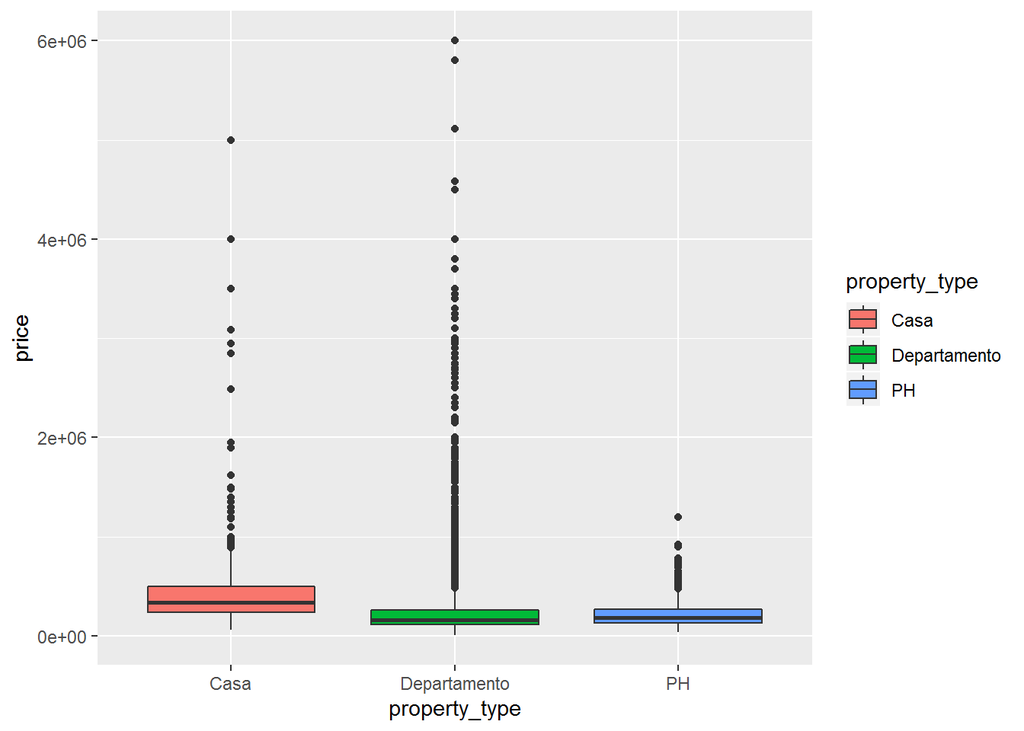

```r
ar_properties_filtrado$price <- as.numeric(as.character(ar_properties_filtrado$price))
ggplot(ar_properties_filtrado, mapping = aes(x = property_type, y = price,
                                   group = property_type, fill = property_type )) +
                                   geom_boxplot()
```

#Una vez más los outliers no nos permiten ver muy bien la comparación entre los boxplots

#d.Realizar un correlagrama usando GGally

```r
library(GGally)
ggallyData <- ar_properties_filtrado %>% select(rooms, bathrooms, surface_total,
                                                surface_covered, price, property_type)
ggallyData$rooms <- as.numeric(as.character(ggallyData$rooms))
ggallyData$bathrooms <- as.numeric(as.character(ggallyData$bathrooms))
ggallyData$surface_total <- as.numeric(as.character(ggallyData$surface_total))
ggallyData$surface_covered <- as.numeric(as.character(ggallyData$surface_covered))
ggallyData$property_type <- as.factor(as.character(ggallyData$property_type))
levels(ggallyData$property_type)
```

```
## [1] "Casa"         "Departamento" "PH"
```

#Departamento 17598 -414 #PH 1831 -414 #Casa 712 -414

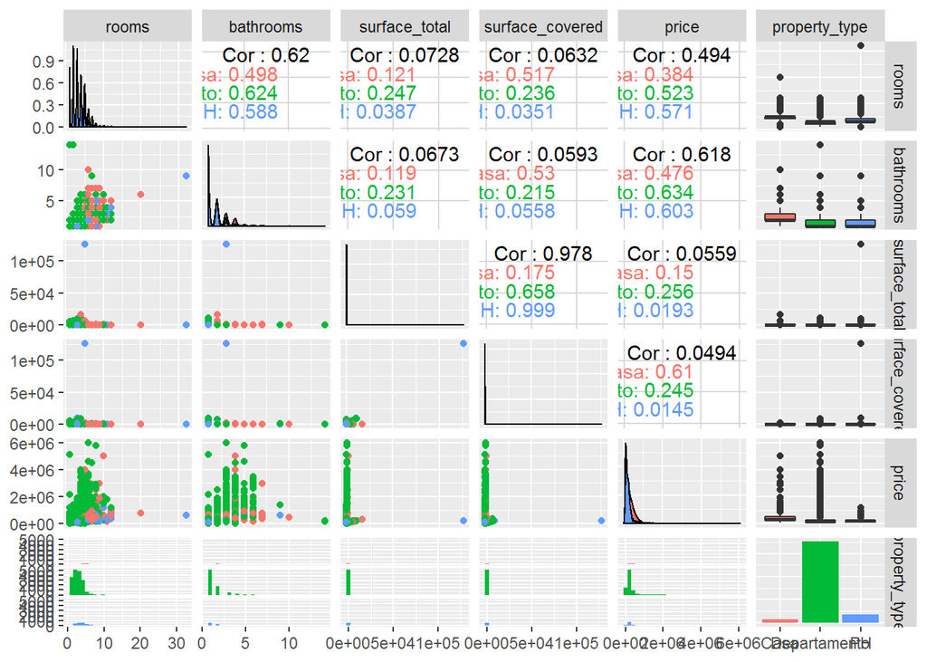

```r
ggpairs(ggallyData,  mapping = aes(color = (ggallyData$property_type)))
```

```r
summaryPrecioPorTipo
```

```
## $PH
##    Min. 1st Qu.  Median    Mean 3rd Qu.    Max.
##   42000  134450  189000  215670  270000 1200000
##
## $Departamento
##    Min. 1st Qu.  Median    Mean 3rd Qu.    Max.
##    6000  114000  163000  246667  260762 6000000
##
## $Casa
##    Min. 1st Qu.  Median    Mean 3rd Qu.    Max.
##   62900  240000  335000  427946  499225 5000000
```

```r
#Si usamos Casa para calcular las distnacias intercuartil
interqDistance <- as.numeric(summaryPrecioPorTipo$Casa[5] - summaryPrecioPorTipo$Casa[3])
interqDistance
```

```
## [1] 164225
```

```r
#Si usamos Departamento para calcular las distnacias intercuartil
interqDistance <- as.numeric(summaryPrecioPorTipo$Departamento[5] - summaryPrecioPorTipo$Departamento[3])
interqDistance
```

```
## [1] 97762.5
```

#Usaremos Departamento, dado que el volumen de datos es muhco mayor para propiedades de este tipo. #Se realizaron experimentos también usando casa, pero el filtro no era tan efectivo como se esperaba.

```r
filter <- as.numeric((interqDistance*3) + summaryPrecioPorTipo$Departamento[5])
filter
```

```
## [1] 554050
```

```r
ggallyDataNoOutliers <- ggallyData %>% filter(ggallyData$price <= filter)
```

#Con esto filtramos un outlier de superficie para un PH que dificulta ver las gráficas

```r
ggallyDataNoOutliers <- ggallyDataNoOutliers %>% filter(ggallyDataNoOutliers$surface_covered < 11000)
summary(ggallyDataNoOutliers)
```

```
##      rooms          bathrooms     surface_total      surface_covered
##  Min.   : 1.000   Min.   : 1.00   Min.   :   12.00   Min.   :    3.00
##  1st Qu.: 2.000   1st Qu.: 1.00   1st Qu.:   44.00   1st Qu.:   40.00
##  Median : 3.000   Median : 1.00   Median :   62.00   Median :   55.00
##  Mean   : 2.638   Mean   : 1.38   Mean   :   84.78   Mean   :   72.53
##  3rd Qu.: 3.000   3rd Qu.: 2.00   3rd Qu.:   94.00   3rd Qu.:   80.00
##  Max.   :12.000   Max.   :14.00   Max.   :16725.00   Max.   :10145.00
##      price             property_type
##  Min.   :  6000   Casa        :  576
##  1st Qu.:114000   Departamento:16347
##  Median :160000   PH          : 1800
##  Mean   :191495
##  3rd Qu.:245000
##  Max.   :550000
```

#El filtro aplicado permite mucha más claridad en los boxplot de precio, además de mayor claridad #en los gráficos de rooms y de bathrooms, puesto que excluye valores de ouliers extremos que allí se tenían.

#Analisis exploratorios (III) #a.Obtener estadisticas descriptivas para la variable precio (cuartiles, promedio, minimo y maximo) y realizar un histograma de la variable

```r
summaryPrecioFiltrado <- summary(as.numeric(as.character(ggallyDataNoOutliers$price)))
summaryPrecioFiltrado
```

```
##    Min. 1st Qu.  Median    Mean 3rd Qu.    Max.
##    6000  114000  160000  191495  245000  550000
```

#El nuevo valormáxmo es $ 550.000es mucho menor que el valor que se tenía antes, sin embargo #es el resultado de expcluir los outliers extremos

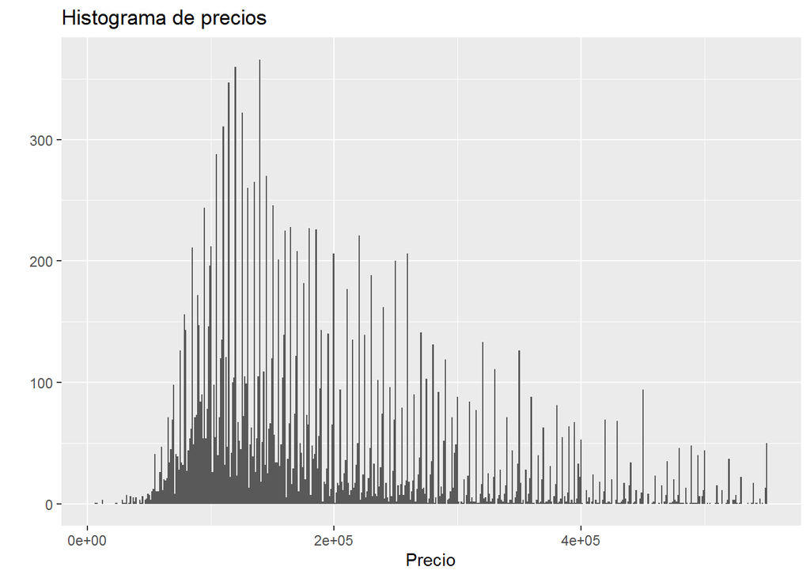

```r
priceHistogramFiltrado <- qplot(as.numeric(as.character(ggallyDataNoOutliers$price)),
                        geom="histogram",
                        main = "Histograma de precios",
                        xlab = "Precio",
                        bins = 500)
priceHistogramFiltrado
```

#El histograma de precios es más claro ahora,se mantiene eso si, siendo una distribucion con cola #a la derecha

#b.Obtener estadisticas descriptivas para la variable precio (cuartiles, promedio, minimo y maximo) por cada tipo de propiedad.

```r
summaryPrecioPorTipoFiltrado <- summary(as.numeric(as.character(ggallyDataNoOutliers$price)))
summaryPrecioPorTipoFiltrado <- tapply(as.numeric(as.character(ggallyDataNoOutliers$price)),
                                       ggallyDataNoOutliers$property_type, summary)
summaryPrecioPorTipoFiltrado <- summaryPrecioPorTipoFiltrado[c("PH","Departamento","Casa")]
summaryPrecioPorTipoFiltrado
```

```
## $PH
##    Min. 1st Qu.  Median    Mean 3rd Qu.    Max.
##   42000  133000  187250  207549  265000  550000
##
## $Departamento
##    Min. 1st Qu.  Median    Mean 3rd Qu.    Max.
##    6000  110000  155000  185661  234950  550000
##
## $Casa
##    Min. 1st Qu.  Median    Mean 3rd Qu.    Max.
##   62900  220000  290000  306892  395000  550000
```

#La media más alta sigue estando para los casos de las casas. Los PH y los Departamentos tienen #medias muy similares #c.Realizar un grafico de boxplot de la variable precio por tipo de propiedad

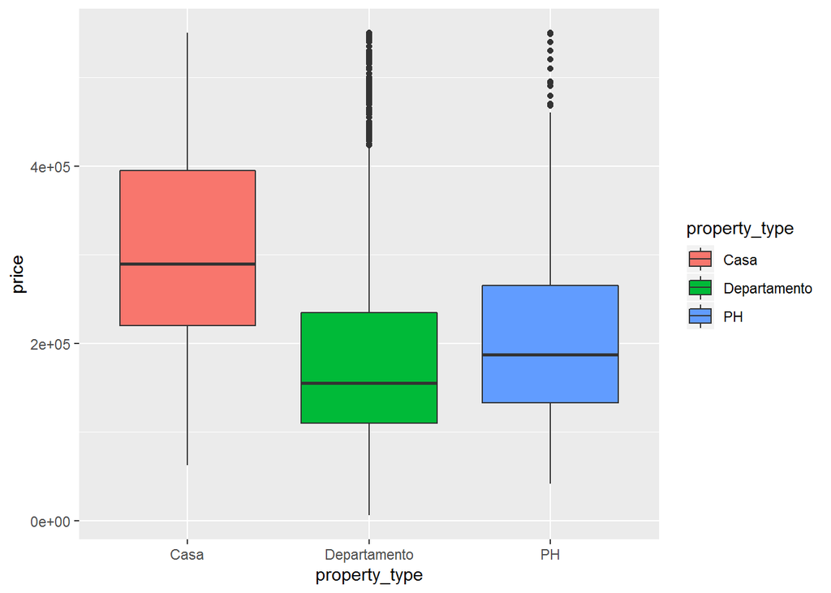

```r
ggallyDataNoOutliers$price <- as.numeric(as.character(ggallyDataNoOutliers$price))
ggplot(ggallyDataNoOutliers, mapping = aes(x = property_type, y = price,
                                         group = property_type, fill = property_type )) +
                                         geom_boxplot()
```

#EL boxplot refleja valores superiores en general para el caso de las casas (puede darse debido a #su tamañoen metros cuadrados y a su mayor cantidad de ambientes) #d.Realizar un correlagrama usando GGAlly

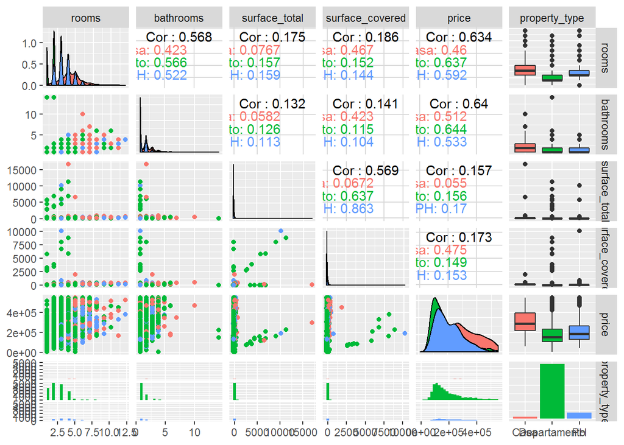

```r
ggpairs(ggallyDataNoOutliers,  mapping = aes(color = (ggallyDataNoOutliers$property_type)))
```

```r
#Añadimos las librerías necesarias:
library(modelr)
library(broom)
```

#Iniciamos con el modelo para las habitaciones

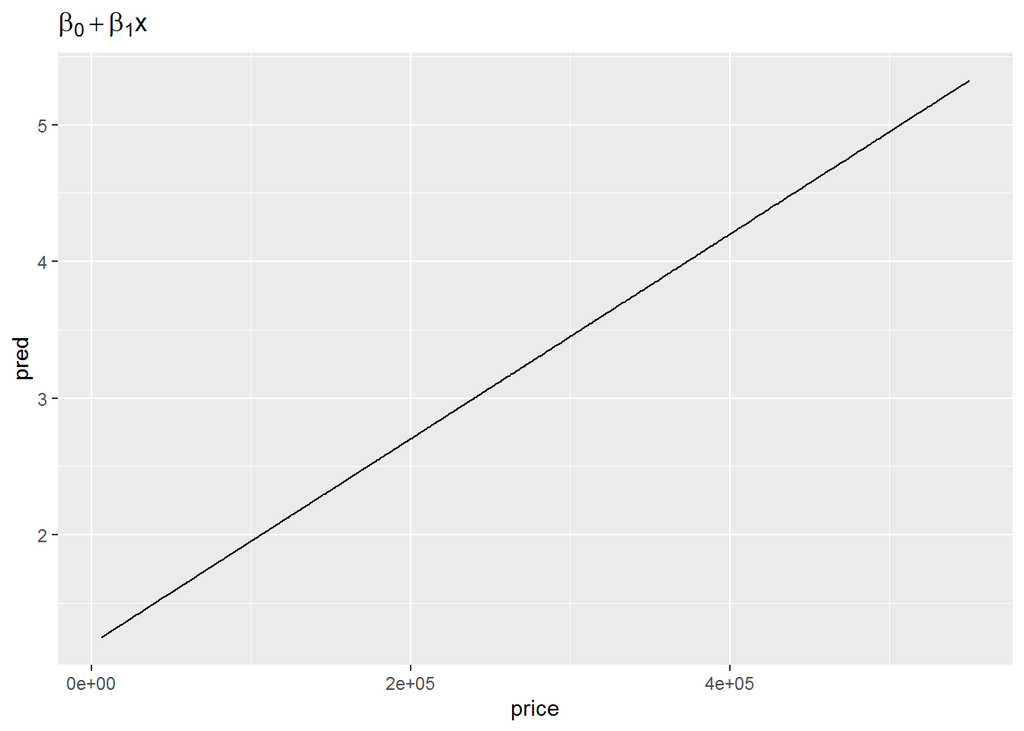

```r
modeloRooms <- lm(rooms ~ price, data = ggallyDataNoOutliers)
ggallyDataNoOutliers %>%
  add_predictions(modeloRooms) %>%
  ggplot(aes(price, pred)) +
  geom_line() +
  ggtitle(expression(beta[0] + beta[1]*x))
```

```r
glance(modeloRooms)
```

| r.squared | adj.r.squared | sigma | statistic | p.value | df | logLik | AIC | BIC | deviance | df.residual |
| --- | --- | --- | --- | --- | --- | --- | --- | --- | --- | --- |
| 0.4024241 | 0.4023922 | 0.9533306 | 12607.24 | 0 | 2 | -25670.95 | 51347.9 | 51371.41 | 17014.38 | 18721 |

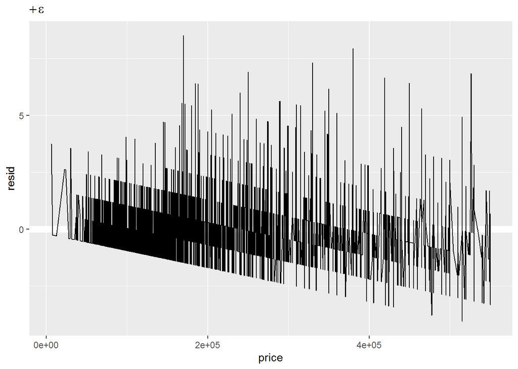

```r
ggallyDataNoOutliers %>%
  add_residuals(modeloRooms) %>%
  ggplot(aes(price, resid)) +
  geom_hline(yintercept = 0, colour = "white", size = 3) +
  geom_line() +
  ggtitle(expression(+ epsilon))
```

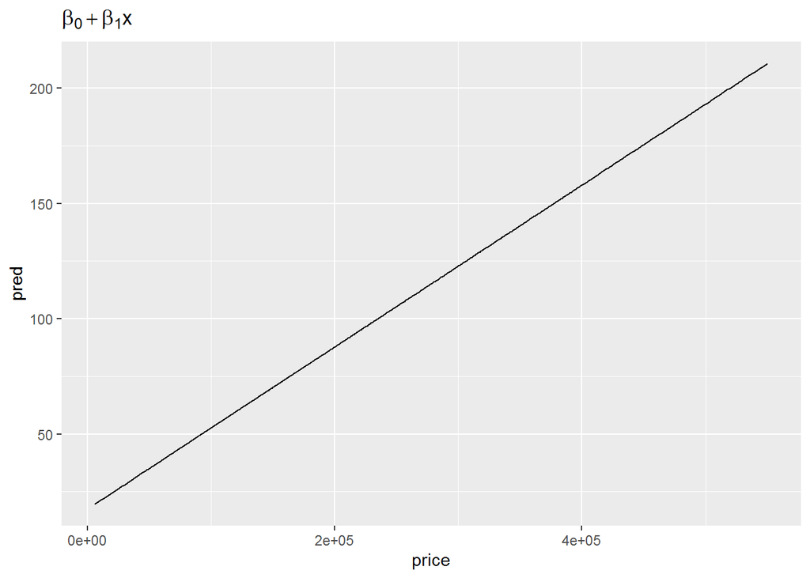

```r
modeloSurface <- lm(surface_total ~ price, data = ggallyDataNoOutliers)
ggallyDataNoOutliers %>%
  add_predictions(modeloSurface) %>%
  ggplot(aes(price, pred)) +
  geom_line() +
  ggtitle(expression(beta[0] + beta[1]*x))
```

```r
glance(modeloSurface)
```

| r.squared | adj.r.squared | sigma | statistic | p.value | df | logLik | AIC | BIC | deviance | df.residual |
| --- | --- | --- | --- | --- | --- | --- | --- | --- | --- | --- |
| 0.0246385 | 0.0245864 | 230.674 | 472.9091 | 1.424749e-103 | 2 | -128437.7 | 256881.5 | 256905 | 996153838 | 18721 |

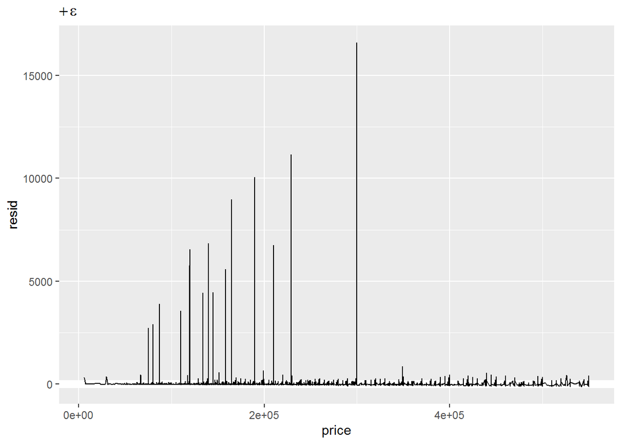

```r
ggallyDataNoOutliers %>%
  add_residuals(modeloSurface) %>%
  ggplot(aes(price, resid)) +
  geom_hline(yintercept = 0, colour = "white", size = 3) +
  geom_line() +
  ggtitle(expression(+ epsilon))
```

#b. Usar la función summary() para obtener informacion de ambos modelos. Explicar los valores de los coeficientes estimados.

```r
summary(modeloRooms)
```

```
##
## Call:
## lm(formula = rooms ~ price, data = ggallyDataNoOutliers)
##
## Residuals:
##     Min      1Q  Median      3Q     Max
## -4.0629 -0.7241 -0.0343  0.5977  8.5227
##
## Coefficients:
##              Estimate Std. Error t value Pr(>|t|)
## (Intercept) 1.203e+00  1.456e-02   82.65   <2e-16 ***
## price       7.494e-06  6.675e-08  112.28   <2e-16 ***
## ---
## Signif. codes:  0 '***' 0.001 '**' 0.01 '*' 0.05 '.' 0.1 ' ' 1
##
## Residual standard error: 0.9533 on 18721 degrees of freedom
## Multiple R-squared:  0.4024, Adjusted R-squared:  0.4024
## F-statistic: 1.261e+04 on 1 and 18721 DF,  p-value: < 2.2e-16
```

```r
summary(modeloSurface)
```

```
##
## Call:
## lm(formula = surface_total ~ price, data = ggallyDataNoOutliers)
##
## Residuals:
##     Min      1Q  Median      3Q     Max
##  -138.9   -22.7   -12.9    -0.6 16602.1
##
## Coefficients:
##              Estimate Std. Error t value Pr(>|t|)
## (Intercept) 1.752e+01  3.522e+00   4.974 6.63e-07 ***
## price       3.512e-04  1.615e-05  21.746  < 2e-16 ***
## ---
## Signif. codes:  0 '***' 0.001 '**' 0.01 '*' 0.05 '.' 0.1 ' ' 1
##
## Residual standard error: 230.7 on 18721 degrees of freedom
## Multiple R-squared:  0.02464,    Adjusted R-squared:  0.02459
## F-statistic: 472.9 on 1 and 18721 DF,  p-value: < 2.2e-16
```